# Lab 1

## Task 1

### Problem 1

- x-axis: income
- y-axis: Life Expectancy
- fill: Region
- size: population
- the year is shown in the background of the visual
- gridlines

```python
import pandas as pd

df = pd.read_csv("/Users/bastiaanweststrate/Desktop/GSB 544/q1data.csv")
```

```python
import numpy as np

from plotnine import (
    ggplot,
    aes,
    geom_point,
    geom_jitter,
    scale_x_continuous,
    geom_boxplot,
    scale_y_continuous,
    labs,
    theme,
    scale_fill_manual,
    scale_size,
    geom_col,
    annotate,
)
```

```
/Users/bastiaanweststrate/Desktop/GSB 544/.venv/lib/python3.9/site-packages/plotnine/layer.py:364: PlotnineWarning: geom_point : Removed 4 rows containing missing values.
```

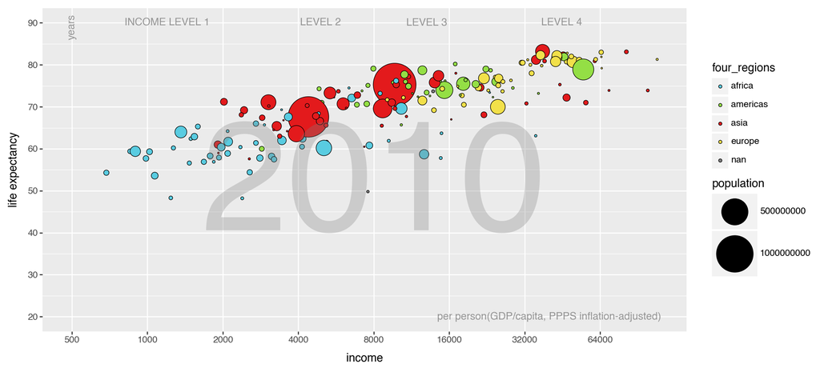

```python
(ggplot(df,aes("income", "life_exp", size ="population"))+geom_point(aes(fill="four_regions"), color = "black", stroke = 0.3)
+ scale_x_continuous(breaks =[500, 1000, 2000, 4000, 8000, 16000, 32000, 64000],
labels = [500, 1000, 2000, 4000, 8000, 16000, 32000, 64000], trans='log2')
+ scale_y_continuous(limits = (20,90), breaks =range (20,91,10))
+ labs(x = "income",
y = "life expectancy")
+ theme(figure_size=(11,5))
+ scale_fill_manual(values = ["#59CCE1", "#94DF45", "#E31A1C", "#F2E04A"])
+ scale_size(range=(0.5,23))
+ annotate("text", x=8000, y=50, label="2010", size=150, color="grey", alpha=.30)
+ annotate("text", x=500, y=89, label="years", size=10, color="grey", alpha=.80, angle=90)
+ annotate("text", x=40000, y=20, label="per person(GDP/capita, PPPS inflation-adjusted)", size=10, color="grey", alpha=.80)
+ annotate("text", x=1200, y=90, label="INCOME LEVEL 1", size=10, color="grey", alpha=.80)
+ annotate("text", x=4900, y=90, label="LEVEL 2", size=10, color="grey", alpha=.80)
+ annotate("text", x=13000, y=90, label="LEVEL 3", size=10, color="grey", alpha=.80)
+ annotate("text", x=45000, y=90, label="LEVEL 4", size=10, color="grey", alpha=.80))
```

# I chose to use a scatter plot with jitter because it makes it easier to see the relationship between income and life expectancy across countries. The jitter helps spread out points that would normally overlap, so the overall pattern is clearer. It’s a good way to spot clusters of countries and to see the general trend that higher income usually goes along with longer life expectancy.

```
/Users/bastiaanweststrate/Desktop/GSB 544/.venv/lib/python3.9/site-packages/plotnine/layer.py:364: PlotnineWarning: geom_jitter : Removed 2 rows containing missing values.
```

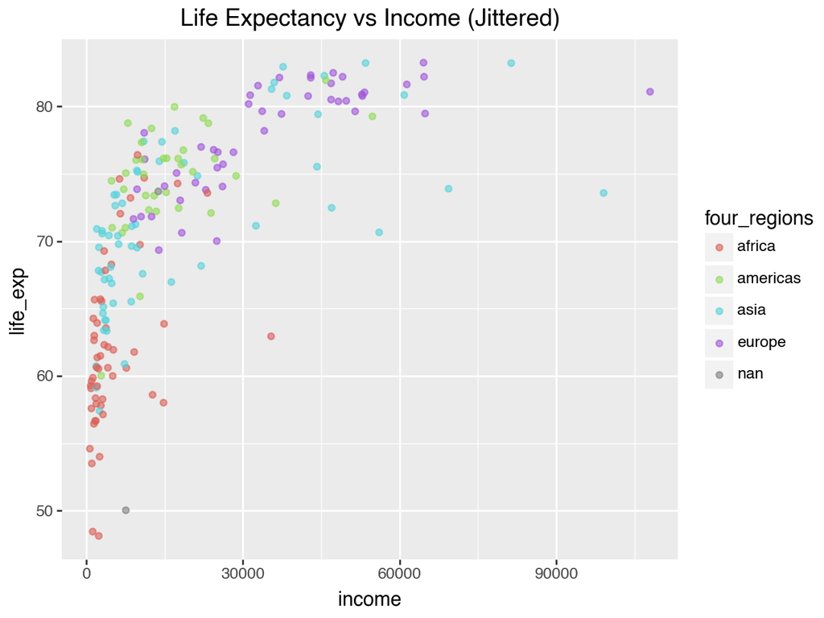

```python
(
    ggplot(df, aes(x="income", y="life_exp", color="four_regions"))
    + geom_jitter(alpha=0.6)
    + labs(title="Life Expectancy vs Income (Jittered)")
)
```

# Task 2

## Aesthetics:

- x-axis: Exports as percentage of GDP
- y-axis: Imports as percentage of GDP
- size: Energy use
- fill: Region
- the year is shown in the background of the visual
- gridlines

```python
df2 = pd.read_csv("/Users/bastiaanweststrate/Desktop/GSB 544/q2data.csv")
```

```python
df2
```

|  | imports | exports | energy | year | country | four_regions | six_regions | eight_regions | world_bank_region |
| --- | --- | --- | --- | --- | --- | --- | --- | --- | --- |
| 0 | NaN | NaN | NaN | 1997 | Afghanistan | asia | south_asia | asia_west | South Asia |
| 1 | 36.7 | 11.5 | 427 | 1997 | Albania | europe | europe_central_asia | europe_east | Europe & Central Asia |
| 2 | 22.5 | 22.6 | 825 | 1997 | Algeria | africa | middle_east_north_africa | africa_north | Middle East & North Africa |
| 3 | NaN | NaN | NaN | 1997 | American Samoa | NaN | NaN | NaN | NaN |
| 4 | NaN | NaN | 434 | 1997 | Angola | africa | sub_saharan_africa | africa_sub_saharan | Sub-Saharan Africa |
| ... | ... | ... | ... | ... | ... | ... | ... | ... | ... |
| 201 | 52.2 | 44.8 | 340 | 1997 | Vietnam | asia | east_asia_pacific | east_asia_pacific | East Asia & Pacific |
| 202 | NaN | NaN | NaN | 1997 | Virgin Islands (U.S.) | NaN | NaN | NaN | NaN |
| 203 | NaN | NaN | 241 | 1997 | Yemen | NaN | NaN | NaN | NaN |
| 204 | 31.6 | 24.6 | 617 | 1997 | Zambia | africa | sub_saharan_africa | africa_sub_saharan | Sub-Saharan Africa |
| 205 | 45.1 | 43.4 | 845 | 1997 | Zimbabwe | africa | sub_saharan_africa | africa_sub_saharan | Sub-Saharan Africa |

206 rows × 9 columns

```python
df2.dtypes
```

```
imports              float64
exports              float64
energy                object
year                   int64
country               object
four_regions          object
six_regions           object
eight_regions         object
world_bank_region     object
dtype: object
```

```python
df2['exports'] = pd.to_numeric(df2['exports'], errors='coerce')
df2['imports'] = pd.to_numeric(df2['imports'], errors='coerce')
df2['energy'] = pd.to_numeric(df2['energy'], errors='coerce')
```

```
/Users/bastiaanweststrate/Desktop/GSB 544/.venv/lib/python3.9/site-packages/plotnine/layer.py:364: PlotnineWarning: geom_point : Removed 80 rows containing missing values.
```

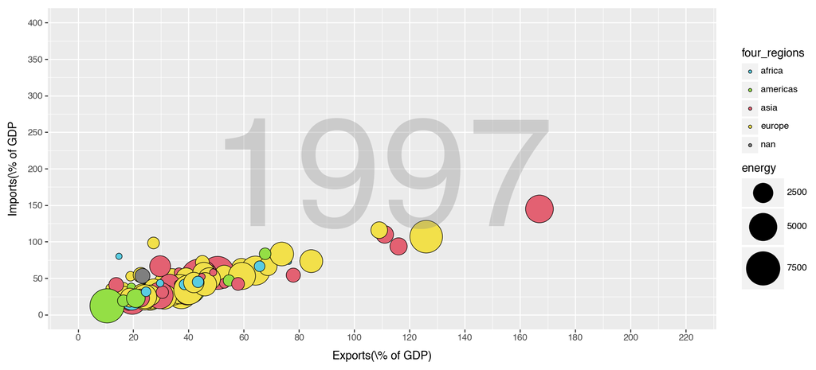

```python
(ggplot(df2,aes("exports", "imports", size ="energy")
)+geom_point(aes(fill="four_regions"), color = "black", stroke = 0.3)
+ scale_x_continuous(limits = (0,220), breaks =range(0,221,20))
+ scale_y_continuous(limits=(0, 400),breaks=range(0, 401, 50))
+ labs(x = "Exports(\% of GDP)", y = "Imports(\% of GDP")
+ theme(figure_size = (11,5))
+ scale_fill_manual(values=["#59CCE1", "#94DF45", "#E36172", "#F2E04A"])
+ scale_size(range=(0.5,20))
+ annotate("text", x=110, y=175, label="1997", size=150, color="grey", alpha=.30))
```

# I used a boxplot because it’s a good way to compare the distribution of imports and exports across different regions. It shows not only the average levels but also the spread and presence of outliers, which helps highlight differences between regions more clearly than a scatterplot would.

```
/Users/bastiaanweststrate/Desktop/GSB 544/.venv/lib/python3.9/site-packages/plotnine/layer.py:284: PlotnineWarning: stat_boxplot : Removed 35 rows containing non-finite values.
/Users/bastiaanweststrate/Desktop/GSB 544/.venv/lib/python3.9/site-packages/plotnine/layer.py:284: PlotnineWarning: stat_boxplot : Removed 35 rows containing non-finite values.
```

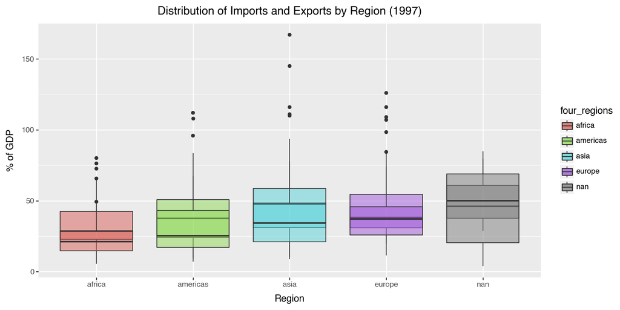

```python
(
    ggplot(df2, aes(x="four_regions", fill="four_regions"))
    + geom_boxplot(aes(y="imports"), alpha=0.5)
    + geom_boxplot(aes(y="exports"), alpha=0.5)
    + labs(
        title="Distribution of Imports and Exports by Region (1997)",
        x="Region",
        y="% of GDP"
    )
    + theme(figure_size=(10, 5))
)
```

# Task 3

## Aesthetics:

- x-axis: individuals using internet
- y-axis: GDP/capita
- size: income
- fill: Region
- the year is shown in the background of the visual
- gridlines

```python
df3 = pd.read_csv("/Users/bastiaanweststrate/Desktop/GSB 544/q3data.csv")
```

```python
df3
```

|  | internet_users | gdp | income | year | country | four_regions | six_regions | eight_regions | world_bank_region |
| --- | --- | --- | --- | --- | --- | --- | --- | --- | --- |
| 0 | 0.00456 | 330.0 | 1190.0 | 2001 | Afghanistan | asia | south_asia | asia_west | South Asia |
| 1 | 0.39000 | 2570.0 | 6780.0 | 2001 | Albania | europe | europe_central_asia | europe_east | Europe & Central Asia |
| 2 | 1.59000 | 3770.0 | 9230.0 | 2001 | Algeria | africa | middle_east_north_africa | africa_north | Middle East & North Africa |
| 3 | NaN | 10500.0 | NaN | 2001 | American Samoa | NaN | NaN | NaN | NaN |
| 4 | 11.30000 | 42600.0 | 35600.0 | 2001 | Andorra | europe | europe_central_asia | europe_west | Europe & Central Asia |
| ... | ... | ... | ... | ... | ... | ... | ... | ... | ... |
| 210 | 1.85000 | 847.0 | 3270.0 | 2001 | Vietnam | asia | east_asia_pacific | east_asia_pacific | East Asia & Pacific |
| 211 | 27.50000 | 36700.0 | NaN | 2001 | Virgin Islands (U.S.) | NaN | NaN | NaN | NaN |
| 212 | 0.51900 | 1190.0 | 4940.0 | 2001 | Yemen | asia | middle_east_north_africa | asia_west | Middle East & North Africa |
| 213 | 0.47800 | 991.0 | 2080.0 | 2001 | Zambia | africa | sub_saharan_africa | africa_sub_saharan | Sub-Saharan Africa |
| 214 | 1.10000 | 1330.0 | 3190.0 | 2001 | Zimbabwe | africa | sub_saharan_africa | africa_sub_saharan | Sub-Saharan Africa |

215 rows × 9 columns

```
/Users/bastiaanweststrate/Desktop/GSB 544/.venv/lib/python3.9/site-packages/plotnine/layer.py:364: PlotnineWarning: geom_point : Removed 32 rows containing missing values.
```

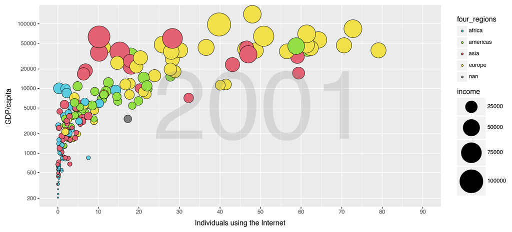

```python
(
ggplot(df3, aes("internet_users", "gdp", size="income"))+ geom_point(aes(fill="four_regions"), color="black",stroke=0.3)
+scale_x_continuous(limits =(0,90), breaks = range(0,91,10))
+ scale_y_continuous(breaks=[200, 500, 1000, 2000, 5000, 10000, 20000, 50000, 100000], labels=[200, 500, 1000, 2000, 5000, 10000, 20000, 50000, 100000],trans="log2")
+ labs(y = "GDP/capita", x = "Individuals using the Internet")
+ theme (figure_size = (11,5))
+ scale_fill_manual(values=["#59CCE1", "#94DF45", "#E36172", "#F2E04A"])
+ scale_size(range=(0.5,20))
+ annotate("text", x=50, y=4000, label="2001", size=150, color="grey", alpha=.20))
```

# I chose a bar chart here because it makes it easier to compare GDP per capita against internet usage across regions. It’s straightforward to see which regions stand out and how the values differ, and the use of color by region makes the differences even clearer.

```
/Users/bastiaanweststrate/Desktop/GSB 544/.venv/lib/python3.9/site-packages/plotnine/layer.py:344: PlotnineWarning: position_stack : Removed 25 rows containing missing values.
/Users/bastiaanweststrate/Desktop/GSB 544/.venv/lib/python3.9/site-packages/plotnine/positions/position.py:232: PlotnineWarning: position_stack requires non-overlapping x intervals
```

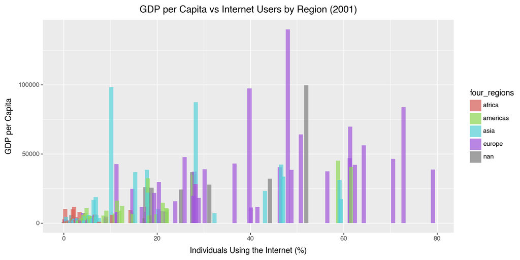

```python
(ggplot(df3, aes(x="internet_users", y="gdp", fill="four_regions"))
+ geom_col(alpha=0.7)
+ labs(
 title="GDP per Capita vs Internet Users by Region (2001)",
x="Individuals Using the Internet (%)",
y="GDP per Capita")
 + theme(figure_size=(10, 5))
)
```